# Estimación del valor π

# 2 Enunciado 1

a). Genere 1 000 coordenadas $x X_{i}^*, ..., X_{1000}^*$. Utilice la distribución uniforme con valor mínimo de 0 y valor máximo de 1. La distribución uniforme genera variables aleatorias que tienen la misma probabilidad de venir de cualquier parte del intervalo $(0, 1)$.

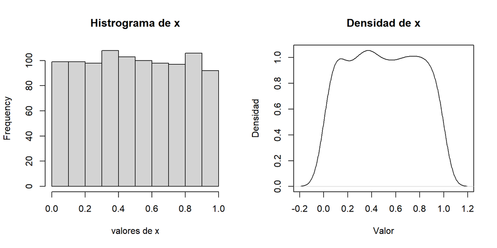

Figura 2. 1000 puntos aleatorios

```r
set.seed(123)
# Definición de la función de prueba
generador <- function(intentos) {
  # Generación de números aleatorios para coordenadas x e y
  assign("x", runif(intentos, min = 0, max = 1), envir = .GlobalEnv)

}

# Ejecución de la función de prueba para diferentes números de intentos
generador(1000)

densidadx <-density(x)


par(mfrow=c(1,2))
hist(x, main="Histrograma de x", xlab="valores de x")

plot(densidadx, main="Densidad de x", xlab = "Valor", ylab = "Densidad")
```

# 3 Enunciado 2

b). Genere 1 000 coordenadas $y Y_{i}^*, ..., Y_{1000}^*$, utilizando nuevamente la distribución uniforme con valor mínimo de 0 y valor máximo de $1$.

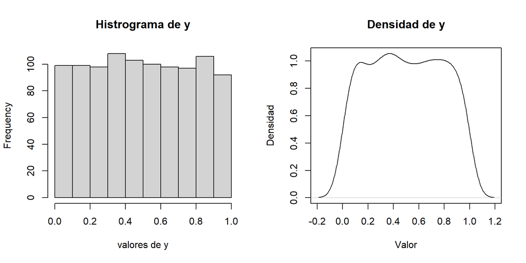

Figura 3. 1000 puntos aleatorios

```r
set.seed(123)


# Definición de la función de prueba
generador <- function(intentos) {
  # Generación de números aleatorios para coordenadas x e y
  assign("y", runif(intentos, min = 0, max = 1), envir = .GlobalEnv)
}

# Ejecución de la función de prueba para diferentes números de intentos
generador(1000)


densidady<- density(y)

par(mfrow=c(1,2))

hist(y, main="Histrograma de y", xlab="valores de y")

plot(densidady, main="Densidad de y", xlab = "Valor", ylab = "Densidad")
```

# 4 Enunciado 3

c). Cada punto $(X_{i}^* , Y_{i}^* )$ se encuentra dentro del círculo si su distancia desde el centro $(0.5, 0.5)$ es menor a $0.5$. Para cada par $(X_{i}^* , Y_{i}^* )$ determine si la distancia desde el centro es menor a $0.5$. Esto último se puede realizar al calcular el valor $(X_{i}^* - 0.5)^2 + (Y_{i}^* - 0.5)^2$ que es el cuadrado de la distancia, y al determinar si es menor que $0.25$.

```r
library("plotrix")
set.seed(123)
conteo <- function(intentos) {
  # Generación de números aleatorios para coordenadas x e y
  assign("x", runif(intentos, min = 0, max = 1), envir = .GlobalEnv)
  assign("y", runif(intentos, min = 0, max = 1), envir = .GlobalEnv)

 # Comprobación de si los puntos caen dentro del círculo unitario centrado en (0.5, 0.5)
    assign("dentro", (x - 0.5)^2 + (y - 0.5)^2 < 0.25, envir = .GlobalEnv)


  # Conteo de intentos correctos (dentro del círculo)
       assign("n_intentos_correctos", sum(dentro), envir = .GlobalEnv)


  # Almacenar los valores dentro y fuera del círculo
  assign("puntos", data.frame(x, y), envir = .GlobalEnv)
    assign("puntos_dentro", puntos[dentro, ], envir = .GlobalEnv)
      assign("puntos_fuera", puntos[!dentro, ], envir = .GlobalEnv)



  # Imprimir la cantidad de intentos correctos y devolver los puntos dentro y fuera del círculo
  print(paste("El número de puntos cuya distancia es menor a 0.5 para esta simulación de", intentos, "puntos es de ",n_intentos_correctos))

}
conteo(100)
```

```
## [1] "El número de puntos cuya distancia es menor a 0.5 para esta simulación de 100 puntos es de  85"
```

```r
#print(list(dentro = puntos_dentro, fuera = puntos_fuera))
```

# 5 Enunciado 4

d). ¿Cuántos de los puntos están dentro del círculo? ¿Cuál es su estimación de $π$? (Nota: Con sólo $1 000$ puntos, es probable que su estimación sea inferior por $0.05$ o más. Una simulación con $10 000$ y $100 000$ puntos tiene mayores probabilidades de dar como resultado una estimación muy cercana al valor verdadero.

## 5.1 Estimación para 1000 puntos.

```r
library("plotrix")
set.seed(123)
simulacion <- function(intentos) {
  # Generación de números aleatorios para coordenadas x e y
  assign("x", runif(intentos, min = 0, max = 1), envir = .GlobalEnv)
  assign("y", runif(intentos, min = 0, max = 1), envir = .GlobalEnv)

 # Comprobación de si los puntos caen dentro del círculo unitario centrado en (0.5, 0.5)
    assign("dentro", (x - 0.5)^2 + (y - 0.5)^2 < 0.25, envir = .GlobalEnv)


  # Conteo de intentos correctos (dentro del círculo)
       assign("n_intentos_correctos", sum(dentro), envir = .GlobalEnv)


  # Almacenar los valores dentro y fuera del círculo
  assign("puntos", data.frame(x, y), envir = .GlobalEnv)
    assign("puntos_dentro", puntos[dentro, ], envir = .GlobalEnv)
      assign("puntos_fuera", puntos[!dentro, ], envir = .GlobalEnv)


       # Conteo de intentos correctos (dentro del círculo)


  # Estimación de pi usando el número de intentos correctos
       assign("pi_estimada", (n_intentos_correctos / intentos) * 4, envir = .GlobalEnv)


  # Impresión del valor estimado de pi


  # Imprimir la cantidad de intentos correctos y devolver los puntos dentro y fuera del círculo
  print(paste("El número de puntos dentro del círculo para esta simulación de", intentos, "es de",n_intentos_correctos))

}
simulacion(1000)
```

```
## [1] "El número de puntos dentro del círculo para esta simulación de 1000 es de 800"
```

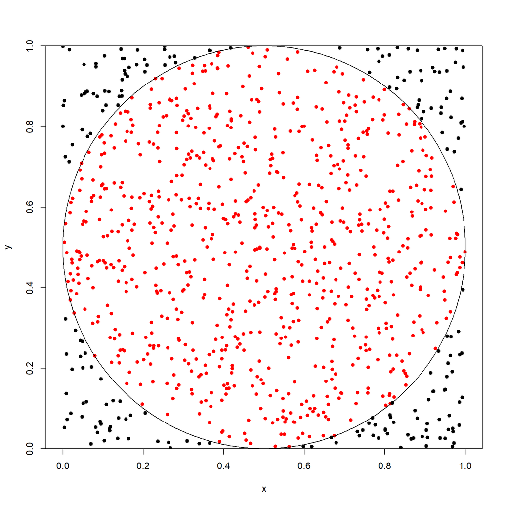

Figura 4. 1000 puntos aleatorios

```r
#print(list(dentro = puntos_dentro, fuera = puntos_fuera))

plot(0,0,asp = 1, xlim = c(0, 1),  ylim = c(0, 1),col="white", xlab="x", ylab="y" , yaxs = "i",  xaxs = "i")
points(puntos_dentro, pch = 21, bg = "red", cex = 0.8, lwd=0.1, col="red")
points(puntos_fuera, pch = 21, bg = "black", cex = 0.8)
#abline(v=1, col="black")
#abline(v=0, col="black")
draw.circle(0.5, 0.5, 0.5, nv = 1000, border = NULL, col = NA, lty = 1, lwd = 1)
```

```r
#Estimación de pi
  print(paste("La estimación de pi para", 1000, "es de:",pi_estimada))
```

```
## [1] "La estimación de pi para 1000 es de: 3.2"
```

```r
  print(paste("La diferencia entre la estimación de pi y el número pi es de", pi_estimada-pi))
```

```
## [1] "La diferencia entre la estimación de pi y el número pi es de 0.0584073464102071"
```

## 5.2 Estimación para 10 000 puntos.

```r
library("plotrix")
set.seed(123)
simulacion <- function(intentos) {
  # Generación de números aleatorios para coordenadas x e y
  assign("x", runif(intentos, min = 0, max = 1), envir = .GlobalEnv)
  assign("y", runif(intentos, min = 0, max = 1), envir = .GlobalEnv)

 # Comprobación de si los puntos caen dentro del círculo unitario centrado en (0.5, 0.5)
    assign("dentro", (x - 0.5)^2 + (y - 0.5)^2 < 0.25, envir = .GlobalEnv)


  # Conteo de intentos correctos (dentro del círculo)
       assign("n_intentos_correctos", sum(dentro), envir = .GlobalEnv)


  # Almacenar los valores dentro y fuera del círculo
  assign("puntos", data.frame(x, y), envir = .GlobalEnv)
    assign("puntos_dentro", puntos[dentro, ], envir = .GlobalEnv)
      assign("puntos_fuera", puntos[!dentro, ], envir = .GlobalEnv)


       # Conteo de intentos correctos (dentro del círculo)


  # Estimación de pi usando el número de intentos correctos
       assign("pi_estimada", (n_intentos_correctos / intentos) * 4, envir = .GlobalEnv)

  # Impresión del valor estimado de pi


  # Imprimir la cantidad de intentos correctos y devolver los puntos dentro y fuera del círculo
    print(paste("El número de puntos dentro del círculo para esta simulación de", intentos, "es de",n_intentos_correctos))

}
simulacion(10000)
```

```
## [1] "El número de puntos dentro del círculo para esta simulación de 10000 es de 7894"
```

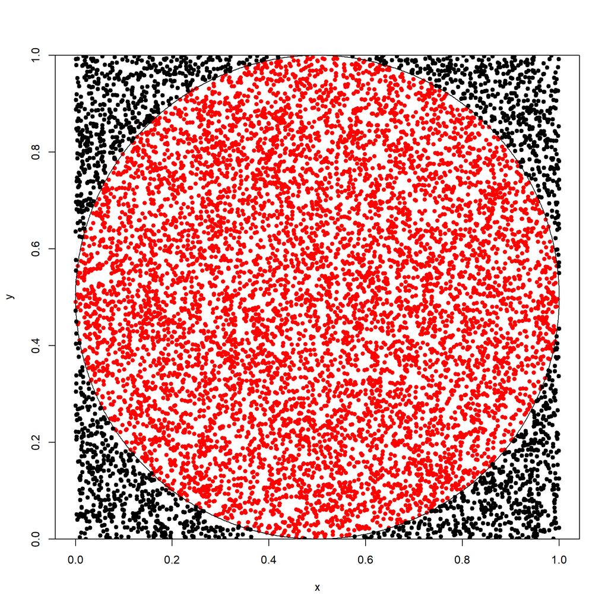

Figura 5. 10000 puntos aleatorios

```r
#print(list(dentro = puntos_dentro, fuera = puntos_fuera))

plot(0,0,asp = 1, xlim = c(0, 1),  ylim = c(0, 1),col="white", xlab="x", ylab="y" , yaxs = "i",  xaxs = "i")
points(puntos_dentro, pch = 21, bg = "red", cex = 0.8, lwd=0.1, col="red")
points(puntos_fuera, pch = 21, bg = "black", cex = 0.8)
#abline(v=1, col="black")
#abline(v=0, col="black")
draw.circle(0.5, 0.5, 0.5, nv = 1000, border = NULL, col = NA, lty = 1, lwd = 1)
```

```r
#Estimación de pi
  print(paste("La estimación de pi para", 10000, "es de:",pi_estimada))
```

```
## [1] "La estimación de pi para 10000 es de: 3.1576"
```

```r
    print(paste("La diferencia entre la estimación de pi y el número pi es de",pi_estimada-pi))
```

```
## [1] "La diferencia entre la estimación de pi y el número pi es de 0.0160073464102068"
```

## 5.3 Estimación de 100 000 puntos

```r
library("plotrix")
set.seed(123)
simulacion <- function(intentos) {
  # Generación de números aleatorios para coordenadas x e y
  assign("x", runif(intentos, min = 0, max = 1), envir = .GlobalEnv)
  assign("y", runif(intentos, min = 0, max = 1), envir = .GlobalEnv)

 # Comprobación de si los puntos caen dentro del círculo unitario centrado en (0.5, 0.5)
    assign("dentro", (x - 0.5)^2 + (y - 0.5)^2 < 0.25, envir = .GlobalEnv)


  # Conteo de intentos correctos (dentro del círculo)
       assign("n_intentos_correctos", sum(dentro), envir = .GlobalEnv)


  # Almacenar los valores dentro y fuera del círculo
  assign("puntos", data.frame(x, y), envir = .GlobalEnv)
    assign("puntos_dentro", puntos[dentro, ], envir = .GlobalEnv)
      assign("puntos_fuera", puntos[!dentro, ], envir = .GlobalEnv)


       # Conteo de intentos correctos (dentro del círculo)


  # Estimación de pi usando el número de intentos correctos
   assign("pi_estimada", (n_intentos_correctos / intentos) * 4, envir = .GlobalEnv)

  # Impresión del valor estimado de pi
options(scipen=9999)

  # Imprimir la cantidad de intentos correctos y devolver los puntos dentro y fuera del círculo
    print(paste("El número de puntos dentro del círculo para esta simulación de", intentos, "es de",n_intentos_correctos))

}
simulacion(100000)
```

```
## [1] "El número de puntos dentro del círculo para esta simulación de 100000 es de 78658"
```

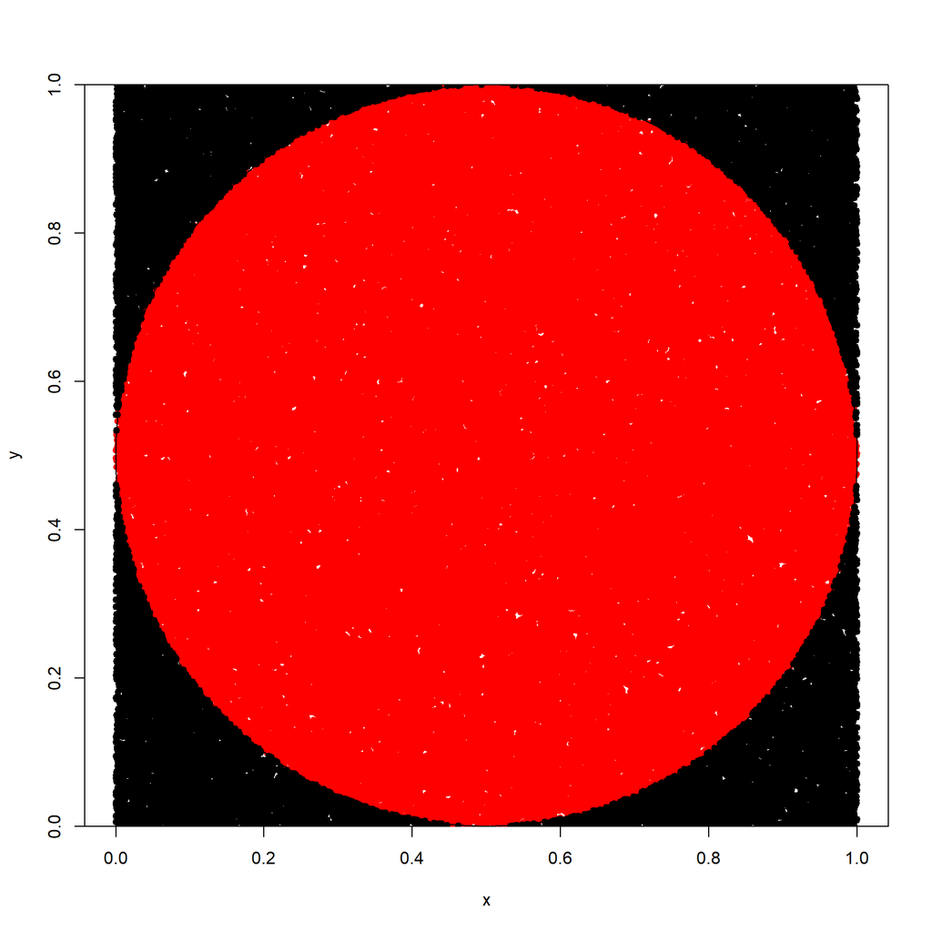

Figura 6. 100000 puntos aleatorios

```r
#print(list(dentro = puntos_dentro, fuera = puntos_fuera))

plot(0,0,asp = 1, xlim = c(0, 1),  ylim = c(0, 1),col="white", xlab="x", ylab="y" , yaxs = "i",  xaxs = "i")
points(puntos_dentro, pch = 21, bg = "red", cex = 0.8, lwd=0.1, col="red")
points(puntos_fuera, pch = 21, bg = "black", cex = 0.8)
#abline(v=1, col="black")
#abline(v=0, col="black")
draw.circle(0.5, 0.5, 0.5, nv = 1000, border = NULL, col = NA, lty = 1, lwd = 1)
```

```r
#Elimina la notación científica
options(scipen=9999)
#Estimación de pi
  print(paste("La estimación de pi para", 100000, "es de:",pi_estimada))
```

```
## [1] "La estimación de pi para 100000 es de: 3.14632"
```

```r
    print(paste("La diferencia entre la estimación de pi y el número pi es de", pi_estimada-pi))
```

```
## [1] "La diferencia entre la estimación de pi y el número pi es de 0.00472734641020667"
```

# Referencias

Navidi, William. 2006. *Estadística Para Ingenieros y Científicos*. McGraw-Hill Interamericana.